# Pipelines to analyze SLE Cut&Run and RNA-seq data

```r
# here i am trying results with no filtering

resNoFiltering = results(dds, independentFiltering = FALSE, cooksCutoff = FALSE, alpha = 0.05)

resNoFiltering

summary(resNoFiltering)
```

```
log2 fold change (MLE): condition knockdown vs control
Wald test p-value: condition knockdown vs control
DataFrame with 61228 rows and 6 columns
              baseMean log2FoldChange     lfcSE       stat    pvalue      padj
             <numeric>      <numeric> <numeric>  <numeric> <numeric> <numeric>
DDX11L2      21.493145      0.0619381  0.261493   0.236863  0.812763  0.995402
DDX11L1       0.342862      0.6790899  2.187692   0.310414  0.756246  0.995402
WASH7P       83.603934      0.0879882  0.184327   0.477347  0.633115  0.995402
MIR6859-1     0.000000             NA        NA         NA        NA        NA
MIR1302-2HG   0.268358      1.1174610  2.284431   0.489164  0.624726  0.995402
...                ...            ...       ...        ...       ...       ...
MT-ND6       2948.0397    -0.25988127  0.463477 -0.5607206  0.574988  0.995402
MT-TE          41.8109     0.00351268  0.452845  0.0077569  0.993811  0.997970
MT-CYB      11683.4577     0.07683123  0.371950  0.2065632  0.836351  0.995402
MT-TT          11.2405     0.18559807  0.394345  0.4706485  0.637892  0.995402
MT-TP         468.6036     0.05226512  0.222270  0.2351420  0.814099  0.995402
```

[output not shown]

```r
# lets create a plot ma using the res variable and then with a shrunken res. This will be with the adj p-vale < 0.1

# first lets shrink the lfc of the res data

resLFC = lfcShrink(dds, coef="condition_knockdown_vs_control", type= "apeglm")

# as you can see we still have the total up and down regulated genes as the normal 'res' data

summary(resLFC)
```

```
using 'apeglm' for LFC shrinkage. If used in published research, please cite:
    Zhu, A., Ibrahim, J.G., Love, M.I. (2018) Heavy-tailed prior distributions for
    sequence count data: removing the noise and preserving large differences.
    Bioinformatics. https://doi.org/10.1093/bioinformatics/bty895
```

```
out of 32876 with nonzero total read count
adjusted p-value < 0.1
LFC > 0 (up)       : 7, 0.021%
LFC < 0 (down)     : 10, 0.03%
outliers [1]       : 0, 0%
low counts [2]     : 20687, 63%
(mean count < 13)
[1] see 'cooksCutoff' argument of ?results
[2] see 'independentFiltering' argument of ?results
```

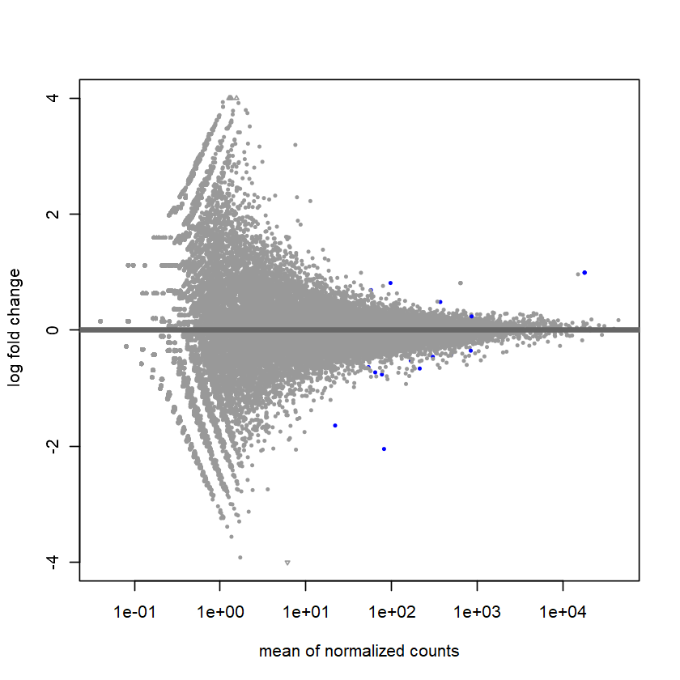

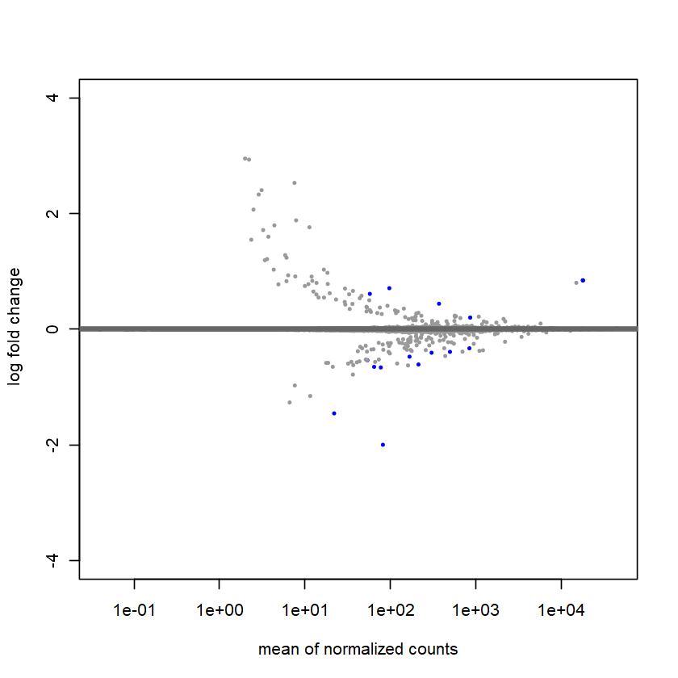

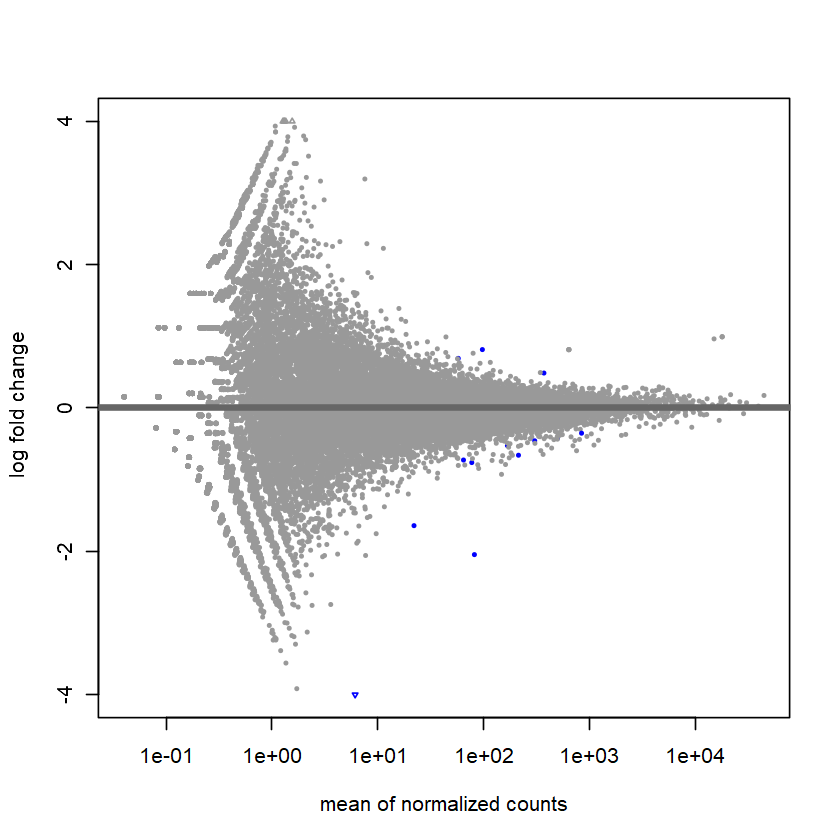

```r
# now plot-ma of res then plot-ma of resLFC

ma_plot_res = plotMA(res, ylim = c(-4,4))
ma_plot_reslfc = plotMA(resLFC, ylim = c(-4,4))
ma_plot_resNoF = plotMA(resNoFiltering, ylim = c(-4,4))

ma_plot_res
ma_plot_reslfc
ma_plot_resNoF
# we are eliminating a lot of noise when shrinking the lfc of our dds data,
# as you can see in the second plot, while retaining the important genes
# the genes removed are low count genes, and we do this without needing to use other filtering thresholds
```

This could be a kind of validation graph. It shows one gene with the lowest p-value between the two conditions each of the points are the replicates of which, we have 12 in total. 6 control replicates (455) and 6 knockdown replicated (454)

So for this gene we see that in all the control replicates its counts were higher and in the knockdown replicates its counts were lower.

I expect since this gene (ELF1) codes for the transcription factor we used in the experiment which was knocked down, the gene will not be stimulated and thus causing its expression to be lower than when the TF is present in the control samples we will expect the gene to be more present because it is stimulated

'ELF1'

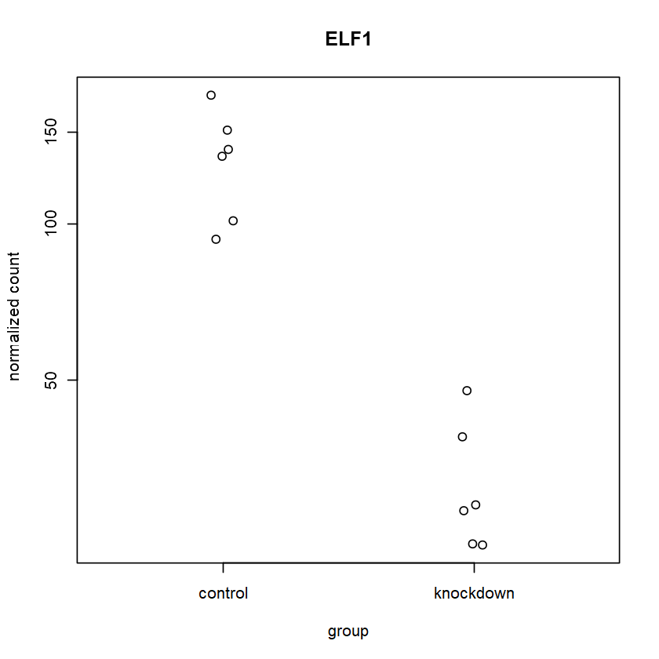

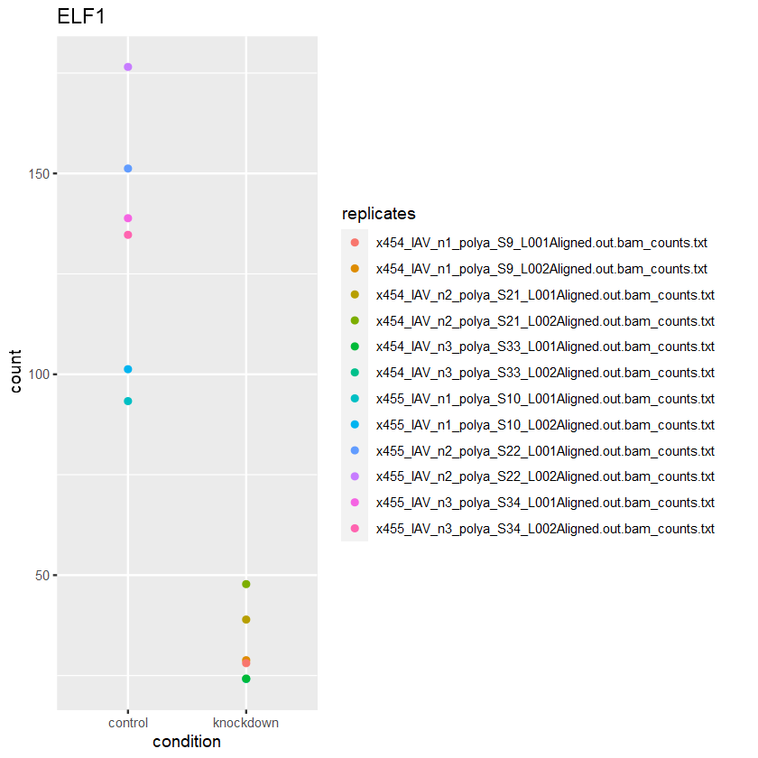

```r
# store the name of the gene that has the lowest padj value
# then extract the row name from this
gene_name = rownames(res[which.min(res$padj),])[1]
gene_name
plotCounts(dds, gene=which.min(res$padj), intgroup="condition")

data_counts = plotCounts(dds, gene=which.min(res$padj), intgroup="condition", returnData = TRUE)

data_counts$replicates = rownames(data_counts)

#ggplot(data_counts, aes(x = condition, y = count)) +
#geom_point() +
#geom_text(aes(label = replicates) , hjust = -0.5, vjust = -0.5)


ggplot(data_counts, aes( x = condition, y = count, color = replicates)) +
geom_point() +
ggtitle(gene_name)


# RAB44
# I can choose any gene_id and check like this
# plotCounts(dds, gene="ENSG00000120690", intgroup="condition")

#ENSG00000120690
```

```r
?plotCounts
```

Now I want to try data transformation with rlog or vst and also blind dispersion estimation. I will not use blind and set it to false because I expect that there will be differences in counts that can be explained by the experimental contditions. If I use blind it will lead to large estimated of dispresion, which comes from linking differences because of conditions to unwanted noise, which is what we should avoid.

```r
# here is the rlog transformation with blind set as false
# explaination above

rld <- rlog(dds, blind=FALSE)

head(assay(rld))
```

A matrix: 6 × 12 of type dbl

|  | x455_IAV_n3_polya_S34_L002Aligned.out.bam_counts.txt | x455_IAV_n3_polya_S34_L001Aligned.out.bam_counts.txt | x455_IAV_n2_polya_S22_L002Aligned.out.bam_counts.txt | x455_IAV_n2_polya_S22_L001Aligned.out.bam_counts.txt | x455_IAV_n1_polya_S10_L002Aligned.out.bam_counts.txt | x455_IAV_n1_polya_S10_L001Aligned.out.bam_counts.txt | x454_IAV_n3_polya_S33_L002Aligned.out.bam_counts.txt | x454_IAV_n3_polya_S33_L001Aligned.out.bam_counts.txt | x454_IAV_n2_polya_S21_L002Aligned.out.bam_counts.txt | x454_IAV_n2_polya_S21_L001Aligned.out.bam_counts.txt | x454_IAV_n1_polya_S9_L002Aligned.out.bam_counts.txt | x454_IAV_n1_polya_S9_L001Aligned.out.bam_counts.txt |
| --- | --- | --- | --- | --- | --- | --- | --- | --- | --- | --- | --- | --- |
| DDX11L2 | 4.384644 | 4.387795 | 4.330298 | 4.312546 | 4.469682 | 4.599496 | 4.319969 | 4.380703 | 4.455052 | 4.369364 | 4.535148 | 4.558047 |
| DDX11L1 | -1.557376 | -1.557275 | -1.557764 | -1.557628 | -1.543913 | -1.543773 | -1.499793 | -1.551718 | -1.555843 | -1.555707 | -1.557544 | -1.557412 |
| WASH7P | 6.435932 | 6.459376 | 6.031888 | 6.291075 | 6.413602 | 6.454659 | 6.363228 | 6.108062 | 6.403232 | 6.369998 | 6.566204 | 6.542791 |
| MIR6859-1 | 0.000000 | 0.000000 | 0.000000 | 0.000000 | 0.000000 | 0.000000 | 0.000000 | 0.000000 | 0.000000 | 0.000000 | 0.000000 | 0.000000 |
| MIR1302-2HG | -1.744920 | -1.744836 | -1.745244 | -1.745131 | -1.733020 | -1.751379 | -1.718477 | -1.740184 | -1.743637 | -1.721762 | -1.745061 | -1.744950 |
| MIR1302-2 | 0.000000 | 0.000000 | 0.000000 | 0.000000 | 0.000000 | 0.000000 | 0.000000 | 0.000000 | 0.000000 | 0.000000 | 0.000000 | 0.000000 |

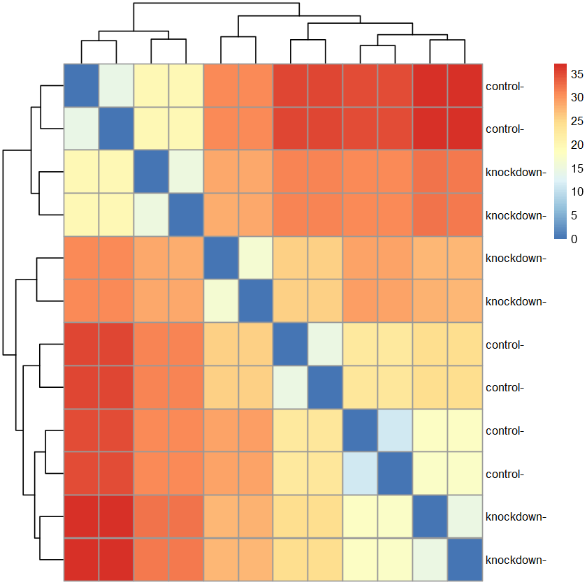

```r
# Now I can find the distance between samples after rlog transformation

library(pheatmap)

sampleDists <- dist(t(assay(rld)))

sampleDistMatrix <- as.matrix(sampleDists)
rownames(sampleDistMatrix) <- paste(rld$condition, rld$type, sep="-")
colnames(sampleDistMatrix) <- NULL

pheatmap(sampleDistMatrix,
         clustering_distance_rows=sampleDists,
         clustering_distance_cols=sampleDists)
```

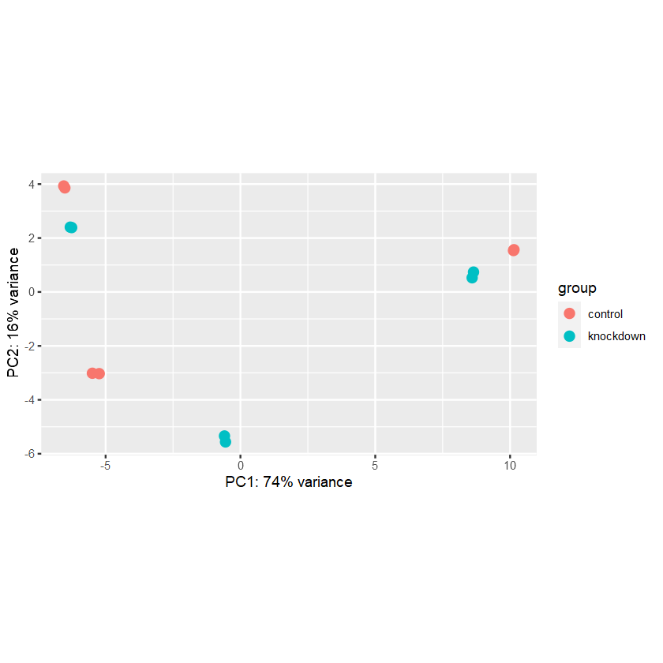

```r
# it looks like PC1 explains 74% of the varince
# we see that one of the groups has an outlier, and that is the knockdown .
# This type of plot is useful for visualizing the overall effect of experimental covariates and batch effects.

plotPCA(rld, intgroup=c("condition"))
```

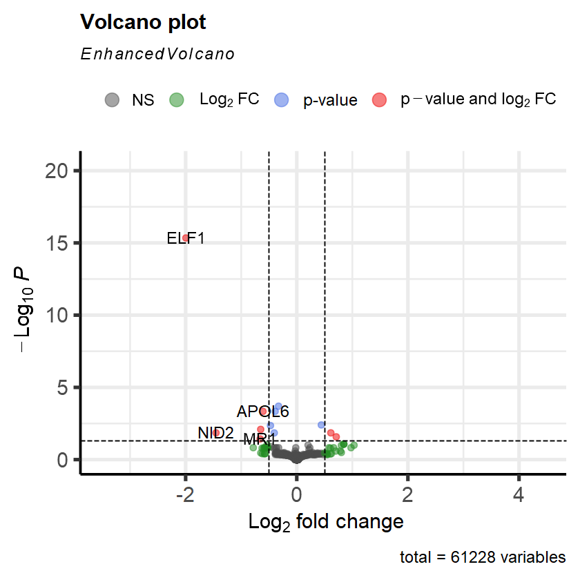

```r
# now I want to create a Volcano plot using the resLFC data
library(EnhancedVolcano)

EnhancedVolcano( resLFC, lab = rownames(resLFC), x = 'log2FoldChange', y = 'padj', pCutoff = 0.05, FCcutoff = 0.5)

# it looks like a good p-adjusted value cutoff for this data would be 0.05.
# a good fold change cutoff should be 0.5, because I am using shrunken log fold change. So the defualt may be too stringent
# So I will grab all of the genes that fall into these two thresholds
```

```r
#?EnhancedVolcano
```

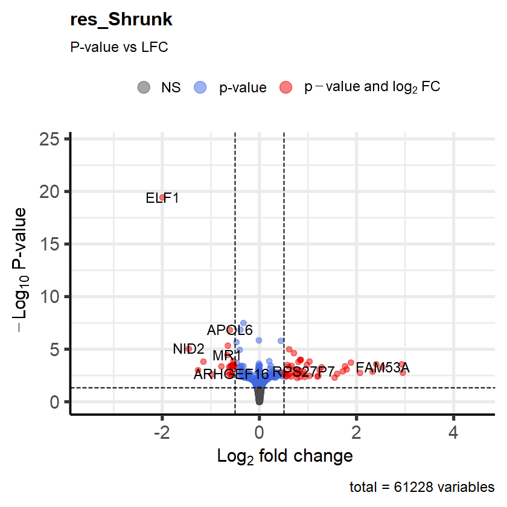

```r
# this is just a volcano plot looking at the pvalue instead of the padj value from above
EnhancedVolcano( resLFC, lab = rownames(resLFC), x = 'log2FoldChange', y = 'pvalue', pCutoff = 0.05 ,
                FCcutoff = 0.5, title = "res_Shrunk", subtitle = "P-value vs LFC",
               xlab = bquote(~Log[2] ~ "fold change"),
                ylab = bquote(~-Log[10] ~ "P-value"),
               legendLabels = c("NS", expression(Log[2] ~ FC), "p-value", expression(p - value ~ and ~ log[2] ~ FC)),)
```

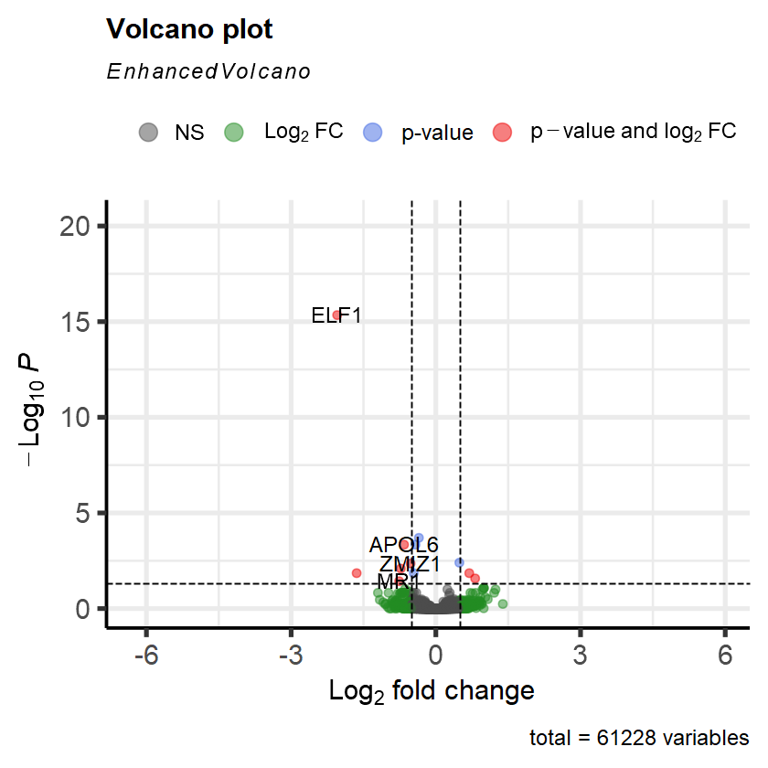

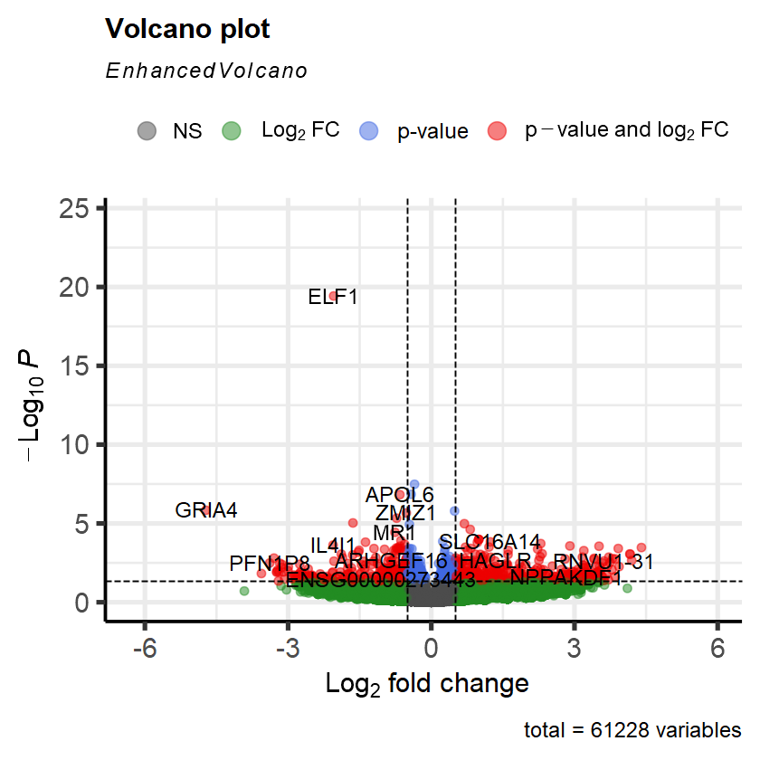

```r
# just checking to see how using res instead of resLFC looks for both padj and pvalue

EnhancedVolcano( res, lab = rownames(res), x = 'log2FoldChange', y = 'padj', pCutoff = 0.05, FCcutoff = 0.5)

EnhancedVolcano( res, lab = rownames(res), x = 'log2FoldChange', y = 'pvalue', pCutoff = 0.05, FCcutoff = 0.5)
```